# Context of Mutations

### Skylar Wyant - 2019/04/12

This notebook details the analysis used to filter the VCF file containing 4 different sequencing runs of the soybean line M92-220

Approximately follows [this tutorial](http://alimanfoo.github.io/2016/06/10/scikit-allel-tour.html).

## Importing data

```python
import numpy as np
import scipy
import pandas
import matplotlib as mpl
import matplotlib.pyplot as plt
%matplotlib inline
import seaborn as sns
sns.set_style('white')
sns.set_style('ticks')
sns.set_context('notebook')
import h5py
import allel; print('scikit-allel', allel.__version__)
import warnings;
warnings.filterwarnings('ignore');
```

```
scikit-allel 1.2.0
```

```python
import os
cwd = os.getcwd()
#print(cwd)
```

```python
chrom = 'Chr20'
file = '/panfs/roc/groups/9/morrellp/shared/Projects/Context_Of_Mutations/M92-220/Genotype_GVCFs/M92-220_complete.vcf'
```

```python
allel.vcf_to_hdf5(file,
                  '/panfs/roc/groups/9/morrellp/shared/Projects/Context_Of_Mutations/M92-220/Genotype_GVCFs/M92-220_' + chrom + '.h5',
                  fields='*',
                  region=chrom,
                  overwrite=True)
```

```python
callset = h5py.File('/panfs/roc/groups/9/morrellp/shared/Projects/Context_Of_Mutations/M92-220/Genotype_GVCFs/M92-220_' + chrom + '.h5', mode='r')
#callset
```

```python
variants = allel.VariantChunkedTable(callset['variants'],
                                     names=['POS', 'REF', 'ALT', 'DP', 'MQ', 'QD', 'AC'],
                                     index='POS')
#variants
```

## Heterozygosity and Missingness

```python
callset = allel.read_vcf(file)
gt = allel.GenotypeArray(callset['calldata/GT'])
index = gt.n_samples
samps = callset['samples']
```

```python
stats = np.ndarray(shape=(4,5), dtype=np.int32)
for i in range(0, index):
        stats.itemset((i, 0), i+1)
        print(str(i+1) + ': ' + str(samps[i]))
        stats.itemset((i, 1), gt[:,i].count_missing())
        stats.itemset((i, 2), gt[:,i].count_het())
        stats.itemset((i, 3), gt[:,i].count_hom_alt())
        stats.itemset((i, 4), gt[:,i].count_het() + gt[:,i].count_hom_alt())
        #print(str(toprint[0]) + '\t' + str(toprint[1]) + '\t' + str(toprint[2]) + '\t' + str(toprint[3]) + '\t' + str(toprint[4]))
```

```
1: M92-220.x1.04.WT_
2: M92-220_10x_illumina
3: M92-220_batch2_combined
4: M92_220_10x_longranger
```

#### Sample Summary

1. The sample from Bolon et al., sequenced with Illumina short reads. Roughly 62x.
2. The same plant that was used for 10x Genomics analysis (#4), but sequenced with Illumina short reads. Roughly 19x.
3. A different plant from the one above, but from the same seed packet. Roughly 108x.
4. The same plant as #2, but sequenced with 10x Genomics linked reads. The BAM file output by Longranger was run through sequence_handling's Haplotype_Caller and Genotype_GVCFs. Roughly 79x.

```python
#print('\tSample\tMissing\tHet\tHom_Alt\tTot_Alt')
#stats
```

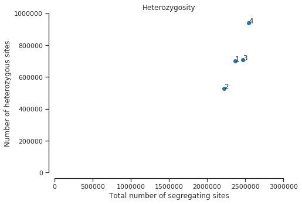

```python
fig, ax = plt.subplots(figsize=(7, 5))
sns.despine(ax=ax, offset=10)
ax.scatter(stats[:,4], stats[:,2])
ax.set_xlim(0, 3000000)
ax.set_ylim(0, 1000000)
ax.set_xlabel('Total number of segregating sites')
ax.set_ylabel('Number of heterozygous sites')
ax.set_title('Heterozygosity')
for i, txt in enumerate(stats[:,0]):
    ax.annotate(txt, (stats[i,4], stats[i,2]))
```

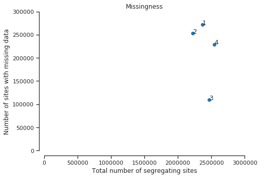

```python
fig, ax = plt.subplots(figsize=(7, 5))
sns.despine(ax=ax, offset=10)
ax.scatter(stats[:,4], stats[:,1])
ax.set_xlim(0, 3000000)
ax.set_ylim(0, 300000)
ax.set_xlabel('Total number of segregating sites')
ax.set_ylabel('Number of sites with missing data')
ax.set_title('Missingness')
for i, txt in enumerate(stats[:,0]):
    ax.annotate(txt, (stats[i,4], stats[i,1]))
```

## Plotting variant density

```python
def plot_windowed_variant_density(pos, window_size, title=None):

    # setup windows
    bins = np.arange(0, pos.max(), window_size)

    # use window midpoints as x coordinate
    x = (bins[1:] + bins[:-1])/2

    # compute variant density in each window
    h, _ = np.histogram(pos, bins=bins)
    y = h / window_size

    # plot
    fig, ax = plt.subplots(figsize=(12, 3))
    sns.despine(ax=ax, offset=10)
    ax.plot(x, y)
    ax.set_xlabel('Chromosome position (bp)')
    ax.set_ylabel('Variant density (bp$^{-1}$)')
    if title:
        ax.set_title(title)
```

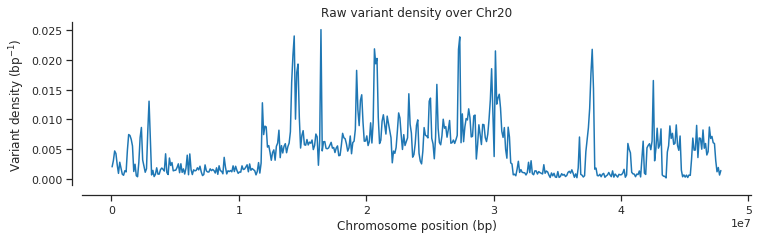

```python
title = 'Raw variant density over ' + chrom
pos = variants['POS'][:]
plot_windowed_variant_density(pos, window_size=100000, title=title)
```

## Plotting variant properties

```python
def plot_variant_hist(x, f, bins=30):
    #x = variants[f][:]
    fig, ax = plt.subplots(figsize=(7, 5))
    sns.despine(ax=ax, offset=10)
    ax.hist(x, bins=bins)
    ax.set_xlabel(f)
    if f == 'DP':
        ax.set_xlim(0, 600)
    if f == 'MQ':
        ax.set_xlim(0, 80)
    ax.set_ylabel('No. variants')
    ax.set_title('Variant %s distribution' % f)
```

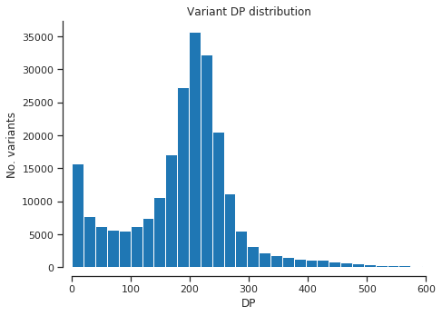

```python
DP = variants['DP'][:]
plot_variant_hist(DP, 'DP', bins=1500)
```

```python
MQ = variants['MQ'][:]
cleanMQ = MQ[np.isfinite(MQ)]
#cleanMQ[:]
```

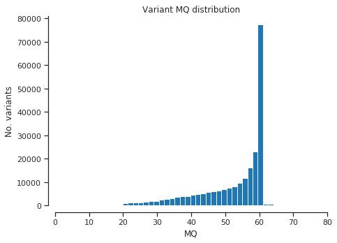

```python
plot_variant_hist(cleanMQ, 'MQ', bins=150)
```

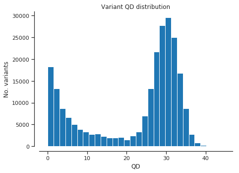

```python
QD = variants['QD'][:]
plot_variant_hist(QD, 'QD')
```

```python
AC = variants['AC'][:]
rows = (AC != -1).sum(1)
#rows
```

```python
biallelic = ((0 < rows) & (rows < 2)).sum()
triallelic = ((1 < rows) & (rows < 3)).sum()
quadrallelic = ((2 < rows) & (rows < 4)).sum()
```

```python
print('Total: ' + str(np.size(rows,0)) + '\nBiallelic: ' + str(biallelic) +
      '\nTriallic: ' + str(triallelic) + '\nQuadrallelic: ' + str(quadrallelic))
```

```
Total: 234328
Biallelic: 231787
Triallic: 2502
Quadrallelic: 39
```

## Ts/Tv Plots

Since you can't calculate Ts/Tv for triallelic sites or insertions/deletions, let's load a version of the VCF file that's only biallelic SNPs. BCFtools was used to do the filtering (-m2 -M2 -v snps)

```python
new_file = '/panfs/roc/groups/9/morrellp/shared/Projects/Context_Of_Mutations/M92-220/Genotype_GVCFs/M92-220_complete_biallelic.vcf'
allel.vcf_to_hdf5(new_file,
                  '/panfs/roc/groups/9/morrellp/shared/Projects/Context_Of_Mutations/M92-220/Genotype_GVCFs/M92-220_' + chrom + '_biallelic.h5',
                  fields='*',
                  region=chrom,
                  overwrite=True)
```

```python
new_callset = h5py.File('/panfs/roc/groups/9/morrellp/shared/Projects/Context_Of_Mutations/M92-220/Genotype_GVCFs/M92-220_' + chrom + '_biallelic.h5', mode='r')
new_variants = allel.VariantChunkedTable(new_callset['variants'],
                                     names=['POS', 'REF', 'ALT', 'DP', 'MQ', 'QD', 'AC'],
                                     index='POS')
#new_variants
```

```python
mutations = new_variants['REF'][:] + new_variants['ALT'][:,0]
#mutations
```

```python
def locate_transitions(x):
    x = np.asarray(x)
    return (x == 'AG') | (x == 'GA') | (x == 'CT') | (x == 'TC')
```

```python
is_ti = locate_transitions(mutations)
#is_ti
```

```python
def ti_tv(x):
    if len(x) == 0:
        return np.nan
    is_ti = locate_transitions(x)
    n_ti = np.count_nonzero(is_ti)
    n_tv = np.count_nonzero(~is_ti)
    if n_tv > 0:
        return n_ti / n_tv
    else:
        return np.nan
```

```python
ti_tv(mutations)
```

```
1.8663412231653969
```

```python
def plot_ti_tv(f, downsample, bins):
    fig, ax = plt.subplots(figsize=(7, 5))
    sns.despine(ax=ax, offset=10)
    x = new_variants[f][:][::downsample]

    # plot a histogram
    ax.hist(x, bins=bins)
    ax.set_xlabel(f)
    ax.set_ylabel('No. variants')

    # plot Ti/Tv
    ax = ax.twinx()
    sns.despine(ax=ax, bottom=True, left=True, right=False, offset=10)
    values = mutations[::downsample]
    with np.errstate(over='ignore'):
        # binned_statistic generates an annoying overflow warning which we can ignore
        y1, _, _ = scipy.stats.binned_statistic(x, values, statistic=ti_tv, bins=bins)
    bx = (bins[1:] + bins[:-1]) / 2
    ax.plot(bx, y1, color='k')
    ax.set_ylabel('Ts/Tv')
    ax.set_ylim(0.5, 3)

    ax.set_title('Variant %s and Ts/Tv' % f)
```

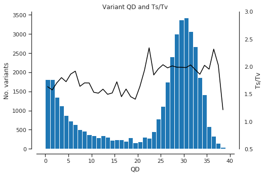

```python
plot_ti_tv('QD', downsample=5, bins=np.arange(0, 40, 1))
```

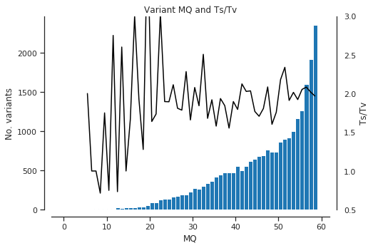

```python
plot_ti_tv('MQ', downsample=5, bins=np.arange(0, 60, 1))
```

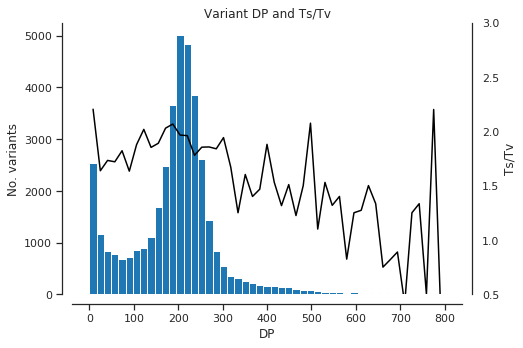

```python
plot_ti_tv('DP', downsample=5, bins=np.linspace(0, 800, 50))
```

```python
def plot_joint_ti_tv(f1, f2, downsample, gridsize=20, mincnt=20, vmin=0.5, vmax=2.5, extent=None):
    fig, ax = plt.subplots()
    sns.despine(ax=ax, offset=10)
    x = new_variants[f1][:][::downsample]
    y = new_variants[f2][:][::downsample]
    C = mutations[::downsample]
    im = ax.hexbin(x, y, C=C, reduce_C_function=ti_tv, mincnt=mincnt, extent=extent,
                   gridsize=gridsize, cmap='jet', vmin=vmin, vmax=vmax)
    fig.colorbar(im)
    ax.set_xlabel(f1)
    ax.set_ylabel(f2)
    ax.set_title('Variant %s versus %s and Ts/Tv' % (f1, f2))
```

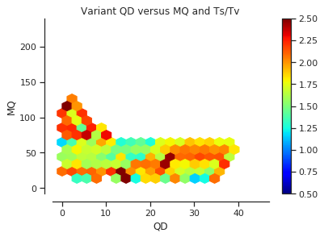

```python
plot_joint_ti_tv('QD', 'MQ', downsample=1, mincnt=30)
```

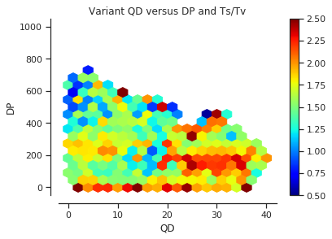

```python
plot_joint_ti_tv('QD', 'DP', downsample=1, mincnt=30, extent=(0, 40, 0, 1000))
```

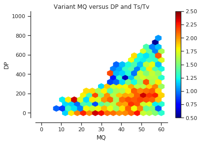

```python
plot_joint_ti_tv('MQ', 'DP', downsample=1, mincnt=30, extent=(0, 60, 0, 1000))
```

## Site Frequency Spectrum

```python
#list(new_callset.keys())
```

```python
calldata = new_callset['calldata/GT']
genotypes = allel.GenotypeChunkedArray(calldata)
#genotypes
```

```python
ac = genotypes.count_alleles(max_allele=3)
#ac[0:50]
```

```python
is_biallelic = ac.is_biallelic_01()[:]
#is_biallelic
```

```python
len(is_biallelic)
```

```
197875
```

```python
ac_bi = ac.compress(is_biallelic, axis=0)[:, :2]
#ac_bi
```

```python
print(str((len(is_biallelic) - len(ac_bi))/len(is_biallelic)*100) +
    '% of variants are called as the alternative allele 100% of the time')
```

```
56.72924826279216% of variants are called as the alternative allele 100% of the time
```

```python
ac_bi_alt = ac_bi[:, 1]
ac_bi_alt
```

```
array([1, 1, 1, ..., 1, 1, 1], dtype=int32)
```

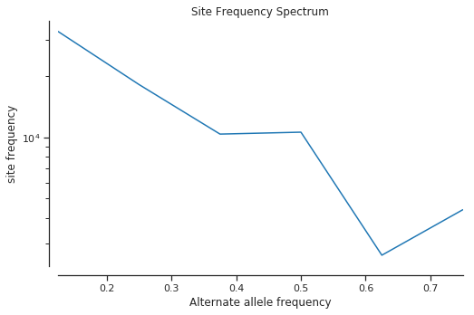

```python
fig, ax = plt.subplots(figsize=(8, 5))
sns.despine(ax=ax, offset=10)
sfs1 = allel.sfs(ac_bi_alt)
allel.plot_sfs(sfs1, ax=ax, n=8)
#ax.set_xlim(0, 1)
#ax.set_ylim(0, 45000)
ax.set_title('Site Frequency Spectrum')
# workaround bug in scikit-allel re axis naming
ax.set_xlabel('Alternate allele frequency');
```

It's "unfolded" in the sense that we care about the frequency of the alternate allele.

If the alternate allele is at a high frequency then it's supported by multiple M92-220 samples, which means it's much more likely to be a real variant.

## Variant Filtering

```python
filter_expression = '(QD > 20) & (MQ > 35) & (DP > 5) & (DP < 500)'
variant_selection = new_variants.eval(filter_expression)[:]
```

Number of remaining variants:

```python
np.count_nonzero(variant_selection)
```

```
125851
```

Percent of variants remaining:

```python
print(str(np.count_nonzero(variant_selection)/len(new_variants)*100) + ' %')
```

```
63.601263423878706 %
```

```python
variants_pass = new_variants.compress(variant_selection)
variants_pass
```

<VariantChunkedTable shape=(125851,) dtype=[('POS', '<i4'), ('REF', 'O'), ('ALT', 'O', (3,)), ('DP', '<i4'), ('MQ', '<f4'), ('QD', '<f4'), ('AC', '<i4', (3,))] nbytes=7.2M cbytes=1.9M cratio=3.8 values=h5py._hl.files.File>

|  | POS | REF | ALT | DP | MQ | QD | AC |  |
| --- | --- | --- | --- | --- | --- | --- | --- | --- |
| 0 | 162 | C | ['T' '' ''] | 368 | 52.06 | 21.87 | [ 1 -1 -1] |  |
| 1 | 1048 | C | ['T' '' ''] | 195 | 56.89 | 34.24 | [ 8 -1 -1] |  |
| 2 | 1098 | G | ['A' '' ''] | 213 | 55.89 | 30.63 | [ 8 -1 -1] |  |
| ... | ... |  |  |  |  |  |  |  |
| 125848 | 47856202 | C | ['T' '' ''] | 388 | 53.03 | 30.67 | [ 2 -1 -1] |  |
| 125849 | 47856220 | A | ['T' '' ''] | 385 | 51.6 | 21.47 | [ 2 -1 -1] |  |
| 125850 | 47859221 | C | ['T' '' ''] | 201 | 59.8 | 29.05 | [ 8 -1 -1] |  |

```python
genotypes_pass = genotypes.compress(variant_selection)
genotypes_pass
```

<GenotypeChunkedArray shape=(125851, 4, 2) dtype=int8 chunks=(125851, 4, 2) nbytes=983.2K cbytes=53.5K cratio=18.4 compression=gzip compression_opts=1 values=h5py._hl.dataset.Dataset>

|  | 0 | 1 | 2 | 3 |  |
| --- | --- | --- | --- | --- | --- |
| 0 | ./. | ./. | ./. | 0/1 |  |
| 1 | 1/1 | 1/1 | 1/1 | 1/1 |  |
| 2 | 1/1 | 1/1 | 1/1 | 1/1 |  |
| ... | ... |  |  |  |  |
| 125848 | 0/1 | 0/1 | 0/0 | 0/0 |  |
| 125849 | 0/1 | 0/1 | 0/0 | 0/0 |  |
| 125850 | 1/1 | 1/1 | 1/1 | 1/1 |  |

```python
mutations_pass = variants_pass['REF'][:] + variants_pass['ALT'][:,0]
ti_tv(mutations_pass)
```

```
1.978157981920583
```

```python
ac_pass = genotypes_pass.count_alleles(max_allele=3)
is_biallelic_pass = ac_pass.is_biallelic_01()[:]
ac_bi_pass = ac_pass.compress(is_biallelic_pass, axis=0)[:, :2]
ac_bi_alt_pass = ac_bi_pass[:, 1]
print(str((len(is_biallelic_pass) - len(ac_bi_pass))/len(is_biallelic_pass)*100) +
    '% of variants are called as the alternative allele 100% of the time')
```

```
84.23214753955074% of variants are called as the alternative allele 100% of the time
```

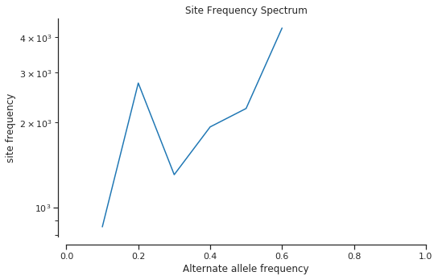

```python
fig, ax = plt.subplots(figsize=(8, 5))
sns.despine(ax=ax, offset=10)
sfs1 = allel.sfs(ac_bi_alt_pass)
allel.plot_sfs(sfs1, ax=ax, n=10)
ax.set_xlim(0, 1)
#ax.set_ylim(0, 45000)
ax.set_title('Site Frequency Spectrum')
# workaround bug in scikit-allel re axis naming
ax.set_xlabel('Alternate allele frequency');
```

```python
gt = genotypes_pass
stats = np.ndarray(shape=(5,5), dtype=np.int32)
for i in range(0, index):
        stats.itemset((i, 0), i+1)
        print(str(i+1) + ': ' + str(samps[i]))
        stats.itemset((i, 1), gt[:,i].count_missing())
        stats.itemset((i, 2), gt[:,i].count_het())
        stats.itemset((i, 3), gt[:,i].count_hom_alt())
        stats.itemset((i, 4), gt[:,i].count_het() + gt[:,i].count_hom_alt())
```

```
1: M92-220.x1.04.WT_
2: M92-220_10x_illumina
3: M92-220_batch2_combined
4: M92_220_10x_longranger
```

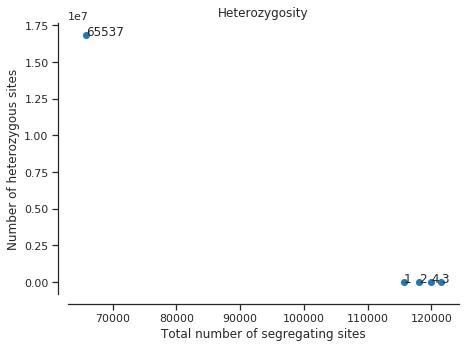

```python
fig, ax = plt.subplots(figsize=(7, 5))
sns.despine(ax=ax, offset=10)
ax.scatter(stats[:,4], stats[:,2])
#ax.set_xlim(0, 5000)
#ax.set_ylim(0, 200)
ax.set_xlabel('Total number of segregating sites')
ax.set_ylabel('Number of heterozygous sites')
ax.set_title('Heterozygosity')
for i, txt in enumerate(stats[:,0]):
    ax.annotate(txt, (stats[i,4], stats[i,2]))
```

```python
%%bash
jupyter nbconvert  --to=html 'M92-220_filtering.ipynb'
```

```
[NbConvertApp] Converting notebook M92-220_filtering.ipynb to html
[NbConvertApp] Writing 805529 bytes to M92-220_filtering.html
```